# **Assignment - 1 : Getting Started**

This assignment will get you familiarized with python libraries required for *data science* and *machine learning*. You will have to complete the code snippets and run them.

## **Note :** Use only the methods and attributes of the `numpy` library. **Do not** hard-code them. Avoid loops as much as possible.

## Part - 1

In this part, you will work with the library `numpy`.

Import `numpy` with an alias name `np`. Initialize two arrays $a$, $b$ of size $3 \times 5$ with random values and print them.

```python
import numpy as np
np.random.seed(0)
a = np.random.rand(3,5)
b = np.random.rand(3,5)
print("A : \n",a)
print("\nB : \n",b)
```

```
A :
 [[0.5488135  0.71518937 0.60276338 0.54488318 0.4236548 ]
 [0.64589411 0.43758721 0.891773   0.96366276 0.38344152]
 [0.79172504 0.52889492 0.56804456 0.92559664 0.07103606]]

B :
 [[0.0871293  0.0202184  0.83261985 0.77815675 0.87001215]
 [0.97861834 0.79915856 0.46147936 0.78052918 0.11827443]
 [0.63992102 0.14335329 0.94466892 0.52184832 0.41466194]]
```

Initialize and print two arrays $c$ and $d$ having the following properties:

- $c$ is a row vector with all non-negative integer values less than 100
- $d$ is a square matrix of size 3 having all entries as 0.0

```python
c = np.asarray([i for i in range(100)])
print("C : \n",c)
d = np.zeros([3,3])
print("\nD : \n",d)
```

```
C :
 [ 0  1  2  3  4  5  6  7  8  9 10 11 12 13 14 15 16 17 18 19 20 21 22 23
 24 25 26 27 28 29 30 31 32 33 34 35 36 37 38 39 40 41 42 43 44 45 46 47
 48 49 50 51 52 53 54 55 56 57 58 59 60 61 62 63 64 65 66 67 68 69 70 71
 72 73 74 75 76 77 78 79 80 81 82 83 84 85 86 87 88 89 90 91 92 93 94 95
 96 97 98 99]

D :
 [[0. 0. 0.]
 [0. 0. 0.]
 [0. 0. 0.]]
```

We have $e$ as following : `e = [[1,2,3],[4,5,6],[7,8,9]]`. Change $e$ as a numpy array and print it.

```python
e = [[1,2,3],[4,5,6],[7,8,9]]
e = np.asarray(e)
print(e)
```

```
[[1 2 3]
 [4 5 6]
 [7 8 9]]
```

$f$ and $g$ are two square matrices of size 5 such that all the entries of $f$ are 1 and $g$ is an identity matrix. Initialize them and print them

```python
f = np.ones((5,5))
print("F :\n",f)
g = np.eye(5)
print("\nG :\n",g)
```

```
F :
 [[1. 1. 1. 1. 1.]
 [1. 1. 1. 1. 1.]
 [1. 1. 1. 1. 1.]
 [1. 1. 1. 1. 1.]
 [1. 1. 1. 1. 1.]]

G :
 [[1. 0. 0. 0. 0.]
 [0. 1. 0. 0. 0.]
 [0. 0. 1. 0. 0.]
 [0. 0. 0. 1. 0.]
 [0. 0. 0. 0. 1.]]
```

Reshape $c$ into a $10 \times 10$ matrix and name it $h$. Now flatten $h$, call it $c^\prime$ and print **YES** when the shapes of $c$ and $c^\prime$ are same. Otherwise print **NO**.

```python
h = np.resize(c,(10,10))
c_dash = h.flatten()
if c.shape==c_dash.shape: print("YES")
else: print("NO")
```

```
YES
```

Let $A$ denote a randomly initialized three dimensional matrix of shape (2,10,5). Transpose $A$, call it $A^\prime$, such that its shape is (5,2,10) and print it.

```python
A = np.random.rand(2,10,5)
A_transpose = np.transpose(A,(2,0,1))
print(A_transpose.shape)
```

```
(5, 2, 10)
```

You have a matrix $X$ of size (10,5) filled with random values. Print the following :

- Minimum value and index where it occured, for each column
- Maximum value and the index where it occured, for each column
- Minimum value and index where it occured, for each row
- Maximum value and index where it occured, for each row
- Minimum value and index where it occured, for the entire matrix
- Maximum value and index where it occured, for the entire matrix

```python
np.random.seed(0)
X = np.random.rand(10,5).astype('f')

def val_index(list_):
    """
    To figure out the indices of the values in list_ present in X.
    """
    index_out = []
    for i in list_:
        index = np.where(X == i)
        index_out.append(list(zip(index[0], index[1])))
    return index_out

def print_val_ind(x,y):
    """
    print out all the values and corresponding indices
    """
    for i,j in zip(x,y):
        print("Value = ",i," Index = ",j)


# minimum value and indices of each column of X
row_min_values = np.amin(X,axis=1)
index_row_min_values = val_index(row_min_values)
# maximum value and indices of each column of X
row_max_values = np.amax(X,axis=1)
index_row_max_values = val_index(row_max_values)
# minimum value and indices of each row of X
col_min_values = np.amin(X,axis=0)
index_col_min_values = val_index(col_min_values)
# maximum value and indices of each row of X
col_max_values = np.amax(X,axis=0)
index_col_max_values = val_index(col_max_values)
# minimum value and its index of the whole matrix
matrix_min_value = np.amin(X)
index_matrix_min_value = np.where(X == matrix_min_value)
index_matrix_min_value = list(zip(index_matrix_min_value[0], index_matrix_min_value[1]))
# maximum value and its index of the whole matrix
matrix_max_value = np.amax(X)
index_matrix_max_value = np.where(X == matrix_max_value)
index_matrix_max_value = list(zip(index_matrix_max_value[0], index_matrix_max_value[1]))


print("Minimum value of columns and their indices")
print_val_ind(col_min_values,index_col_min_values)
print("\nMaximum value of columns and their indices")
print_val_ind(col_max_values,index_col_max_values)
print("\nMinimum value of rows and their indices")
print_val_ind(row_min_values,index_row_min_values)
print("\nMaximum value of rows and their indices")
print_val_ind(row_max_values,index_row_max_values)
print("\nMinimum value of the whole Matrix X and its index")
print("Value = ",matrix_min_value," Index = ",index_matrix_min_value)
print("\nMaximum value of the whole Matrix X and its index")
print("Value = ",matrix_max_value," Index = ",index_matrix_max_value)
```

[output not shown]

Find and print the following for the matrix X:

- Mean of each row and column
- Standard deviation of each row and column
- Mean of the entire matrix
- Standard deviation of entire matrix

```python
print("The Mean and Standard Deviation of each Row of the Matrix X :")
count = [i for i in range(X.shape[0])]
for i,j,k in zip(count,np.mean(X,axis=1),np.std(X,axis=1)):
    print("The mean for row : ",i," is : ",j," with standard deviation : ",k )

print("\nThe Mean and Standard Deviation of each Column of the Matrix X :")
count = [i for i in range(X.shape[1])]
for i,j,k in zip(count,np.mean(X,axis=0),np.std(X,axis=0)):
    print("The mean for column : ",i," is : ",j," with standard deviation : ",k )

print("\nThe mean for the entire Matrix X is : ",np.mean(X))
print("\nThe standard deviation for the entire Matrix X is : ",np.std(X))
```

```
The Mean and Standard Deviation of each Row of the Matrix X :
The mean for row :  0  is :  0.5670608  with standard deviation :  0.09445298
The mean for row :  1  is :  0.66447175  with standard deviation :  0.23322985
The mean for row :  2  is :  0.57705945  with standard deviation :  0.29189733
The mean for row :  3  is :  0.5176273  with standard deviation :  0.3805299
The mean for row :  4  is :  0.627612  with standard deviation :  0.30431634
The mean for row :  5  is :  0.5328907  with standard deviation :  0.26338416
The mean for row :  6  is :  0.41643268  with standard deviation :  0.2584144
The mean for row :  7  is :  0.6944467  with standard deviation :  0.12727958
The mean for row :  8  is :  0.44423264  with standard deviation :  0.23169975
The mean for row :  9  is :  0.33781716  with standard deviation :  0.1853733

The Mean and Standard Deviation of each Column of the Matrix X :
The mean for column :  0  is :  0.56044376  with standard deviation :  0.24687646
The mean for column :  1  is :  0.46781453  with standard deviation :  0.25752157
The mean for column :  2  is :  0.6200991  with standard deviation :  0.22948615
The mean for column :  3  is :  0.6402513  with standard deviation :  0.28054145
The mean for column :  4  is :  0.40121683  with standard deviation :  0.26584905

The mean for the entire Matrix X is :  0.53796506

The standard deviation for the entire Matrix X is :  0.27226582
```

Let $Y$ denote a square matrix of size 10 with random values. Print the following:

- Determinant
- Rank of the matrix
- Diagonal Elements
- Trace
- Eigen values
- Matrices obtained after Singular Value Decomposition
- Inverse if exists, otherwise Pseudo-Inverse
- Multiplication $Y$ with $X$
- Element-wise multiplication of $Y$ and its inverse(or pseudo-inverse)

```python
np.random.seed(3)
Y = np.random.rand(10,10).astype('f')
diag = [Y[i,i] for i in range(Y.shape[0])]
print("Determinant of Y : ",np.linalg.det(Y))
print("Rank of Y : ",np.linalg.matrix_rank(Y))
print("The Diagonal Elements are : ",diag)
print("Trace of Y : ",np.trace(Y))
print("Eigen Values of Y : \n",np.linalg.eig(Y)[0])

u,s,vh = np.linalg.svd(Y,full_matrices=True)
# Y = U*S*Vt by svd

print("The Matrices obtained on SVD of Y are : ")
print("Matrix U : \n",u)
print("Matrix S : \n",s)
print("Matrix Vt : \n",vh)
print("Inverse of Y : \n",np.linalg.inv(Y))
print("Multiplication of Y with X : \n",np.matmul(Y,X))
print("Element wise multiplication : \n",Y@np.linalg.inv(Y))
```

```
Determinant of Y :  -0.012807809
Rank of Y :  10
The Diagonal Elements are :  [0.5507979, 0.4568332, 0.4404537, 0.84575087, 0.4576864, 0.3621762, 0.061528932, 0.19897602, 0.9267257, 0.19638057]
Trace of Y :  4.4973097
Eigen Values of Y :
 [ 4.797525  +0.j          0.72411406+0.5223818j   0.72411406-0.5223818j
 -0.48250064+0.55413675j -0.48250064-0.55413675j -0.6909002 +0.j
 -0.2590566 +0.32357377j -0.2590566 -0.32357377j  0.21278551+0.08352476j
  0.21278551-0.08352476j]
The Matrices obtained on SVD of Y are :
Matrix U :
 [[-0.31776407 -0.02455511 -0.60644877 -0.17883356 -0.12672162  0.14873871
  -0.17823945 -0.5285945  -0.02295864 -0.38570884]
 [-0.26118514 -0.10864542 -0.24911353  0.26547363  0.521684   -0.25773907
  -0.46995324  0.21752644 -0.3928504   0.16234496]
 [-0.31347907 -0.34483472 -0.25292295  0.1214296   0.14869638  0.33436325
   0.54080224  0.48017168  0.05660696 -0.20966421]
 [-0.3581538   0.5949002   0.3025516   0.15850614 -0.11046297  0.3051409
   0.07395529  0.03044895 -0.5056166  -0.18384856]
 [-0.28385845 -0.18085696 -0.15830778  0.10535531 -0.46807835 -0.08377642
   0.24075456 -0.16170762 -0.2478695   0.6920165 ]
 [-0.28871349 -0.27577123  0.40271106  0.60433656  0.11931678 -0.04899206
   0.02593319 -0.44875148  0.2787474  -0.12964799]
 [-0.27897316  0.00398904  0.20819752 -0.5253662   0.4111689  -0.41991907
   0.42687228 -0.24145621 -0.12958513 -0.00984812]
 [-0.24788529  0.48136836 -0.15792437 -0.02303901  0.3246308   0.25755957
  -0.01429536 -0.03088374  0.5605249   0.4407926 ]
 [-0.37505168 -0.3672858   0.39799374 -0.451868   -0.10830046  0.3445676
  -0.44474027  0.14147954  0.07167252  0.09192695]
 [-0.400496    0.19846101 -0.02705461  0.0250083  -0.39745057 -0.57941616
  -0.10288204  0.36739558  0.33321488 -0.22039138]]
Matrix S :
 [4.8963666  1.428321   1.1717339  0.94068766 0.7689225  0.62457275
 0.5210595  0.28969577 0.24512275 0.09350223]
Matrix Vt :
 [[-0.28816736 -0.35560524 -0.33294234 -0.33250663 -0.3665819  -0.3625847
  -0.2657325  -0.23278667 -0.30457184 -0.29270443]
 [ 0.536935    0.11306853  0.3956208   0.2509972  -0.0736956  -0.37753546
  -0.08584362  0.0033361  -0.23990218 -0.5162398 ]
 [-0.084609   -0.22589746 -0.00306935  0.19542387 -0.327784   -0.49318925
```

[output cut: 63 more lines]

```
 [ 6.80238088e-09 -5.02739788e-08 -8.08713239e-08  1.64677374e-08
   1.67841662e-07  1.00000000e+00 -5.26438626e-09  4.14224175e-08
  -6.68125644e-09 -3.31802674e-08]
 [-3.12752064e-08  5.21491827e-09  5.40270904e-08  8.06693379e-10
  -6.21038367e-08  6.25492049e-08  1.00000000e+00  5.19735721e-09
   6.65116850e-09  8.02309330e-08]
 [-7.39831165e-08  4.89386132e-08  4.88374283e-08 -1.10489630e-07
  -7.05810237e-08  1.73706489e-08  2.75095147e-08  1.00000000e+00
  -1.44579682e-09  9.71282432e-08]
 [-4.40672778e-08  1.45338355e-08 -1.03511368e-08 -5.47547074e-09
   5.73206336e-08 -1.49746541e-07 -4.82966520e-08  1.73631491e-07
   9.99999940e-01  5.92321605e-08]
 [-7.40040775e-08 -1.43142307e-08  7.53654206e-08 -7.78787594e-08
  -1.03538028e-07 -5.17164755e-09 -2.45985596e-08 -3.43197897e-08
   4.00495814e-08  1.00000000e+00]]
```

## End of Part - 1

## Part - 2

In this part, you will be working with the library `pandas`. Import this library with an alias name `pd`.

```python
# Initial imports
import numpy as np
import matplotlib.pyplot as plt
import pandas as pd
%matplotlib inline
```

Download dataset from: http://biostat.mc.vanderbilt.edu/wiki/pub/Main/DataSets/titanic3.csv Read the data and display the first 5 rows

```python
#Download dataset from: http://biostat.mc.vanderbilt.edu/wiki/pub/Main/DataSets/titanic3.csv

file_url = "http://biostat.mc.vanderbilt.edu/wiki/pub/Main/DataSets/titanic3.csv"
df = pd.read_csv(file_url)
df.head(5)
```

|  | pclass | survived | name | sex | age | sibsp | parch | ticket | fare | cabin | embarked | boat | body | home.dest |
| --- | --- | --- | --- | --- | --- | --- | --- | --- | --- | --- | --- | --- | --- | --- |
| 0 | 1 | 1 | Allen, Miss. Elisabeth Walton | female | 29.00 | 0 | 0 | 24160 | 211.3375 | B5 | S | 2 | NaN | St Louis, MO |
| 1 | 1 | 1 | Allison, Master. Hudson Trevor | male | 0.92 | 1 | 2 | 113781 | 151.5500 | C22 C26 | S | 11 | NaN | Montreal, PQ / Chesterville, ON |
| 2 | 1 | 0 | Allison, Miss. Helen Loraine | female | 2.00 | 1 | 2 | 113781 | 151.5500 | C22 C26 | S | NaN | NaN | Montreal, PQ / Chesterville, ON |
| 3 | 1 | 0 | Allison, Mr. Hudson Joshua Creighton | male | 30.00 | 1 | 2 | 113781 | 151.5500 | C22 C26 | S | NaN | 135.0 | Montreal, PQ / Chesterville, ON |
| 4 | 1 | 0 | Allison, Mrs. Hudson J C (Bessie Waldo Daniels) | female | 25.00 | 1 | 2 | 113781 | 151.5500 | C22 C26 | S | NaN | NaN | Montreal, PQ / Chesterville, ON |

### Preprocessing of the Dataset

**1. Convert the categorical values of columns 'sex', 'embarked', 'pclass' into dummy values and add them into titanic_data_new DataFrame**

```python
col = ['sex','embarked','pclass']
titanic_data_new = pd.get_dummies(df[col])
```

**2. Fill the missing data in Age and Fare columns with the mean value of the respected column then add these columns to titanic_data_new**

```python
col = ['age','fare']
df[col] = df[col].fillna(df.mean())
titanic_data_new = pd.concat([df[col],titanic_data_new],axis=1)
titanic_data_new.head(5)
```

|  | age | fare | pclass | sex_female | sex_male | embarked_C | embarked_Q | embarked_S |
| --- | --- | --- | --- | --- | --- | --- | --- | --- |
| 0 | 29.00 | 211.3375 | 1 | 1 | 0 | 0 | 0 | 1 |
| 1 | 0.92 | 151.5500 | 1 | 0 | 1 | 0 | 0 | 1 |
| 2 | 2.00 | 151.5500 | 1 | 1 | 0 | 0 | 0 | 1 |
| 3 | 30.00 | 151.5500 | 1 | 0 | 1 | 0 | 0 | 1 |
| 4 | 25.00 | 151.5500 | 1 | 1 | 0 | 0 | 0 | 1 |

### Normalization

1. Normalize the columns which have numerical data

```python
from sklearn.preprocessing import MinMaxScaler
sc = MinMaxScaler()
#col = ['sex','embarked','pclass','age','fare']
titanic = df.select_dtypes(exclude=['object'])
titanic_sc = pd.DataFrame(sc.fit_transform(titanic))
titanic_sc.head()
```

|  | 0 | 1 | 2 | 3 | 4 | 5 | 6 |
| --- | --- | --- | --- | --- | --- | --- | --- |
| 0 | 0.0 | 1.0 | 0.361142 | 0.000 | 0.000000 | 0.412503 | NaN |
| 1 | 0.0 | 1.0 | 0.009395 | 0.125 | 0.222222 | 0.295806 | NaN |
| 2 | 0.0 | 0.0 | 0.022924 | 0.125 | 0.222222 | 0.295806 | NaN |
| 3 | 0.0 | 0.0 | 0.373669 | 0.125 | 0.222222 | 0.295806 | 0.409786 |
| 4 | 0.0 | 0.0 | 0.311036 | 0.125 | 0.222222 | 0.295806 | NaN |

1. Drop the original age, fare columns
2. Append the normalized columns to the titanic_data_new DataFrame.

```python
df.drop(['age','fare'],axis=1)
out_data = pd.concat([titanic_data_new,titanic_sc],axis=1)
```

### Plotting

1. plot the age against the ID(continuous)
2. plot the fare against the ID(scatter)

```
(1.0, 1309.0)
```

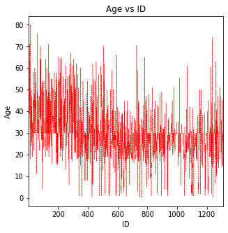

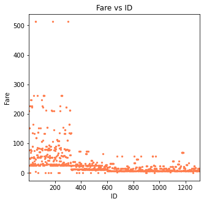

```python
index = [i for i in range(1,df.shape[0]+1)]
plt.figure(figsize=(5,5))
plt.plot(index,out_data['age'],'--r',linewidth=0.5)
plt.title("Age vs ID")
plt.xlabel("ID")
plt.ylabel("Age")
plt.xlim([1,index[-1]])

plt.figure(figsize=(5,5))
plt.scatter(index,out_data['fare'],c='coral',s=5)
plt.title("Fare vs ID")
plt.xlabel("ID")
plt.ylabel("Fare")
plt.xlim([1,index[-1]])
```

## End of Part - 2

## Part - 3

In this part, you will work with the library `matplotlib`. Import the `pyplot` from `matplotlib` with an alias name `plt`.

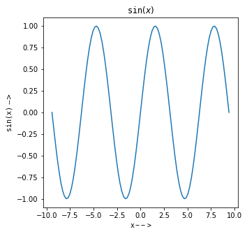

```python
x = np.linspace(-3*np.pi,3*np.pi,100)
y = np.sin(x)
plt.figure(figsize=(5,5))
plt.plot(x,y)
plt.xlabel(r"$\mathtt{x -->}$")
plt.ylabel(r"$\mathtt{sin(x)}$ -->")
plt.title(r"$\mathtt{sin}(x)$")
```

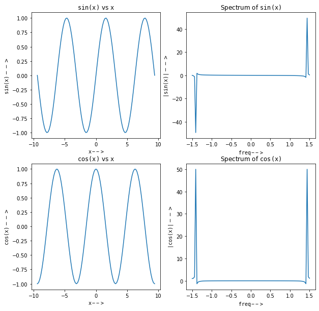

```python
plt.figure(figsize=(10,10))

plt.subplot(221)
fft_sinx = np.fft.fft(y)
plt.plot(x,y)
plt.title(r"$\mathtt{sin(x)}$ vs $\mathtt{x}$")
plt.xlabel(r"$\mathtt{x -->}$")
plt.ylabel(r"$\mathtt{sin(x)} -->$")

plt.subplot(222)
plt.plot(x/(2*np.pi),-fft_sinx.imag)
plt.title(r"Spectrum of $\mathtt{sin(x)}$")
plt.xlabel(r"$\mathtt{freq -->}$")
plt.ylabel(r"$\mathtt{|sin(x)|} -->$")


plt.subplot(223)
z = np.cos(x)
fft_cosx = np.fft.fft(z)
plt.plot(x,z)
plt.title(r"$\mathtt{cos(x)}$ vs $\mathtt{x}$")
plt.xlabel(r"$\mathtt{x -->}$")
plt.ylabel(r"$\mathtt{cos(x)} -->$")


plt.subplot(224)
plt.plot(x/(2*np.pi),-fft_cosx.real)
plt.title(r"Spectrum of $\mathtt{cos(x)}$")
plt.xlabel(r"$\mathtt{freq -->}$")
plt.ylabel(r"$\mathtt{|cos(x)|} -->$")
```

## End of Part - 3

Create a Github repository with the name *SHALA2020* and save this assignment there.